# SBS96 matrix downsampling

Ellie Dunstone

2023-02-16

## Introduction

This script is for adjusting a mutation matrix so that samples with unusually high numbers of mutation calls are downsampled, avoiding them from over-contributing to a signature extraction process. This is generally only required when you have a large amount of variation in mutation numbers between your samples - e.g. you have both normal samples and tumour samples; tumour samples including hypermutators; or a range of normal samples including highly-mutated tissues like the epidermis.

The exact threshold over which samples will be downsampled is somewhat arbitary; a number of ways of deciding this threshold may work equally well, and the best method may depend on the specifics of your dataset.

It should be noted that changing the absolute number of mutation calls will mean that any statistics generated during your signature extraction process (number of mutations per signature, confidence intervals of signature extractions) will be with reference to your new downsampled input matrix, not the original data. For the number of mutations, this can be corrected using the original matrix counts (or burden estimates if using NanoSeq data). For signature extraction confidence intervals this is not as easy, but these intervals are not widely used and if anything the degree of error will be overestimated, which may not be an issue.

## Read in data

First, read in the raw counts of SBS96 mutations. This script was developed using ‘SigProfiler’ format matrices, so if yours is in a different format it may need some manipulation. The first column should list the 96 mutation types, with the remaining columns corresponding to each sample.

```r
#read in your original matrix
og_matrix <- read_table("/Users/ed4/Documents/phd/chemo_project/scripts/nanoseq_scripts/nanoseq_output_processing/matrix_downsampling/trint_subs_matrix_corrected.tsv")
```

## Calculate and visualise mutation counts per sample

We now want to calculate the raw number of mutations called per sample.

```r
raw_muts_total <- as.data.frame(colSums(og_matrix[,-1]))
raw_muts_total <- as.data.frame(cbind(sample = rownames(raw_muts_total), total_muts = raw_muts_total[,1]))
raw_muts_total[,2] <- as.numeric(raw_muts_total[,2])
```

We can now plot the distribution of the mutation sums.

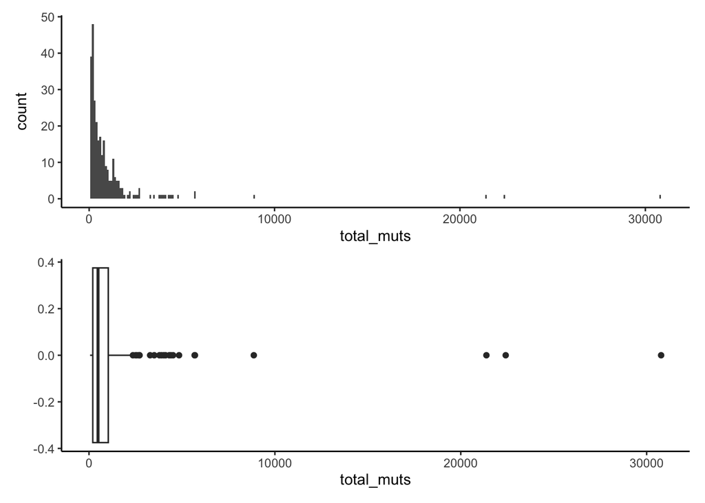

```r
total_muts_hist <- ggplot(raw_muts_total) +
  geom_histogram(aes(total_muts), binwidth = 100) +
  theme_classic()

total_muts_box <- ggplot(raw_muts_total) +
  geom_boxplot(aes(total_muts)) +
  theme_classic()

total_muts_hist/total_muts_box
```

These plots can be used to determine a sensible threshold for downsampling.

The upper whisker extends from the 75th percentile to the largest value no further than 1.5 * IQR from the 75th percentile (where IQR is the inter-quartile range, or distance between the first and third quartiles). The lower whisker extends from the 25th percentile to the smallest value at most 1.5 * IQR of the 25th percentile. Outliers are plotted individually.

## Calculate downsampling threshold

Here, I will downsample outliers to approximately the 75th percentile of the total mutation number + 1.5 * IQR, essentially reducing them to the level of non-outlying samples.

The threshold is calculated as follows:

$$Downsampling\ threshold = 75th\ percentile + 1.5*(75th\ percentile -
25th\ percentile)$$

```r
quartiles <- quantile(raw_muts_total$total_muts) #calculate quartiles and min/max of the data
print(quartiles)
```

```
##    0%   25%   50%   75%  100%
##    58   204   486  1037 30778
```

```r
thresh <- quartiles[4] + 1.5 * (quartiles[4] - quartiles[2])
print(paste0("The suggested threshold for downsampling is ", thresh))
```

```
## [1] "The suggested threshold for downsampling is 2286.5"
```

## Identify samples and downsampling factors

We will now identify the samples with total mutation calls above the threshold, and the extent to which they need to be downsampled.

```r
#identify samples above threshold
above_thresh <- filter(raw_muts_total, total_muts > thresh)

print(paste0("There are ", as.character(nrow(above_thresh)), " samples to be downsampled, with mutation counts between ", as.character(min(above_thresh$total_muts)), " and ", as.character(max(above_thresh$total_muts))))
```

```
## [1] "There are 22 samples to be downsampled, with mutation counts between 2363 and 30778"
```

```r
#calculate downsampling factors
above_thresh <- mutate(above_thresh, ds_factor = thresh/total_muts)
```

## Downsampling

We will now downsample the identified outliers by simple rescaling of the appropriate columns of the mutation matrix according to the corresponding downsampling factors, followed by rounding to the nearest integer to give simulated count data. You could also achieve a similar effect using multinomial sampling, if you wish to introduce sampling noise while simulating the downsampled samples, but this has not been implemented here.

```r
#init downsampled matrix
ds_matrix <- og_matrix[,1]

#downsample selected samples
for (i in 2:ncol(og_matrix)) {
  if (colnames(og_matrix)[i] %in% above_thresh$sample) {
    print(paste0("Downsampling sample ", colnames(og_matrix)[i], "..."))
    ds_matrix[,i] <- round(og_matrix[,i]*above_thresh$ds_factor[above_thresh$sample==colnames(og_matrix)[i]], 0)
  } else {
    ds_matrix[,i] <- og_matrix[,i]
  }
}
```

```
## [1] "Downsampling sample S1..."
## [1] "Downsampling sample S2..."
## [1] "Downsampling sample S14..."
## [1] "Downsampling sample S22..."
## [1] "Downsampling sample S27..."
## [1] "Downsampling sample S28..."
## [1] "Downsampling sample S55..."
## [1] "Downsampling sample S56..."
## [1] "Downsampling sample S57..."
## [1] "Downsampling sample S58..."
## [1] "Downsampling sample S83..."
## [1] "Downsampling sample S95..."
## [1] "Downsampling sample S96..."
## [1] "Downsampling sample S99..."
## [1] "Downsampling sample S102..."
## [1] "Downsampling sample S103..."
## [1] "Downsampling sample S166..."
## [1] "Downsampling sample S167..."
## [1] "Downsampling sample S170..."
## [1] "Downsampling sample S171..."
## [1] "Downsampling sample S279..."
## [1] "Downsampling sample S280..."
```

## Check distribution

We now want to check that the new distribution of total mutation counts per sample has changed appropriately.

```r
ds_muts_total <- as.data.frame(colSums(ds_matrix[,-1]))
ds_muts_total <- as.data.frame(cbind(sample = rownames(ds_muts_total), total_muts = ds_muts_total[,1]))
ds_muts_total[,2] <- as.numeric(ds_muts_total[,2])
```

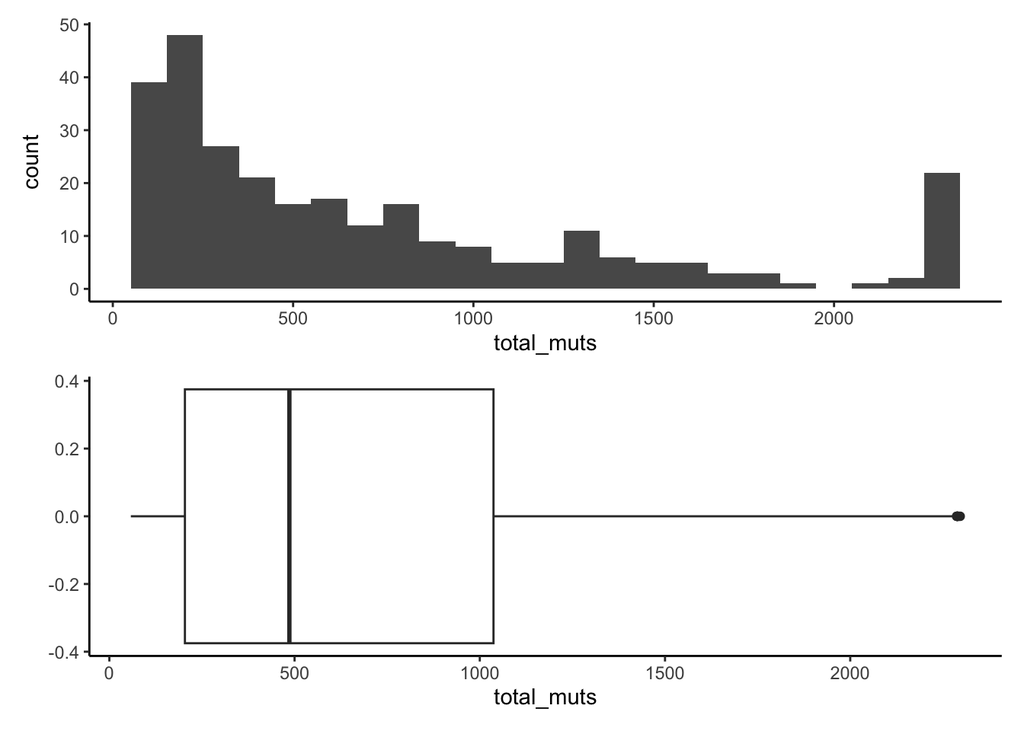

```r
ds_muts_hist <- ggplot(ds_muts_total) +
  geom_histogram(aes(total_muts), binwidth = 100) +
  theme_classic()

ds_muts_box <- ggplot(ds_muts_total) +
  geom_boxplot(aes(total_muts)) +
  theme_classic()

ds_muts_hist/ds_muts_box
```

## Wrapper function

The above process is also implemented as a function, using which you can downsample either using a threshold calculated based on the distribution of your data, or using your own custom threshold. This function does not currently produce the plots generated in this script, so I strongly recommend plotting the data yourself before running this to check that this method is suitable.

### Parameters:

mutation matrix: SBS96 mutation matrix as tab-separated file, in ‘SigProfiler’ format (see https://github.com/AlexandrovLab/SigProfilerExtractor). The first column should list the 96 mutation types, with the remaining columns corresponding to the raw mutation counts for each sample.

ds_thresh: This function will calculate the threshold for number of mutation calls above which to downsample your samples. However, if you wish to override this calculation and use your own threshold, you can specify it here.

### Returns:

Function returns your downsampled mutation matrix. In future I would also like to add returning the ds_thresh value calculated, and boxplots and histograms of mutation count distribution before and after downsampling.

### Usage:

Example 1:

```r
sbs96_downsample(og_matrix)
```

Downsamples samples from the matrix that are above a threshold calculated based on the distribution of your data

Example 2:

```r
sbs96_downsample(og_matrix, ds_thresh = 5000)
```

Downsamples samples from the matrix that have over 5000 total mutations.

```r
##Note - this should really be implemented by sourcing the matrix_downsampling_SBS96_function.R script, but I'm struggling to get this working without using absolute paths?

#Assign sbs_downsample function

sbs96_downsample <- function(mutation_matrix, ds_thresh=NULL) {

  #calculate raw mutation totals per sample
  raw_muts_total <- as.data.frame(colSums(mutation_matrix[,-1]))
  raw_muts_total <- as.data.frame(cbind(sample = rownames(raw_muts_total), total_muts = raw_muts_total[,1]))
  raw_muts_total[,2] <- as.numeric(raw_muts_total[,2])

  #calculate downsampling threshold if not provided
  if (is.null(ds_thresh)) {
    quartiles <- quantile(raw_muts_total$total_muts) #calculate quartiles and min/max of the data
    thresh <- quartiles[4] + 1.5 * (quartiles[4] - quartiles[2])
    print(paste0("The suggested threshold for downsampling is ", thresh))
  } else {
    thresh <- ds_thresh #if threshold provided manually, assign
  }

  #identify samples above threshold
  above_thresh <- filter(raw_muts_total, total_muts > thresh)

  print(paste0("There are ", as.character(nrow(above_thresh)), " samples to be downsampled, with mutation counts between ", as.character(min(above_thresh$total_muts)), " and ", as.character(max(above_thresh$total_muts))))

  #calculate downsampling factors
  above_thresh <- mutate(above_thresh, ds_factor = thresh/total_muts)

  #init downsampled matrix
  ds_matrix <- mutation_matrix[,1]

  #downsample selected samples
  for (i in 2:ncol(mutation_matrix)) {
    if (colnames(mutation_matrix)[i] %in% above_thresh$sample) {
      print(paste0("Downsampling sample ", colnames(mutation_matrix)[i], "..."))
      ds_matrix[,i] <- round(mutation_matrix[,i]*above_thresh$ds_factor[above_thresh$sample==colnames(mutation_matrix)[i]], 0)
    } else {
      ds_matrix[,i] <- mutation_matrix[,i]
    }
  }

  #return the downsampled matrix
  return(ds_matrix)
}
```

We can now use the function to generate the same result as above, or to downsample to a custom threshold of 5000 mutations:

```r
#downsample with custom threshold calculation as above
ds_matrix <- sbs96_downsample(og_matrix)
```

```
## [1] "The suggested threshold for downsampling is 2286.5"
## [1] "There are 22 samples to be downsampled, with mutation counts between 2363 and 30778"
## [1] "Downsampling sample S1..."
## [1] "Downsampling sample S2..."
## [1] "Downsampling sample S14..."
## [1] "Downsampling sample S22..."
## [1] "Downsampling sample S27..."
## [1] "Downsampling sample S28..."
## [1] "Downsampling sample S55..."
## [1] "Downsampling sample S56..."
## [1] "Downsampling sample S57..."
## [1] "Downsampling sample S58..."
## [1] "Downsampling sample S83..."
## [1] "Downsampling sample S95..."
## [1] "Downsampling sample S96..."
## [1] "Downsampling sample S99..."
## [1] "Downsampling sample S102..."
## [1] "Downsampling sample S103..."
## [1] "Downsampling sample S166..."
## [1] "Downsampling sample S167..."
## [1] "Downsampling sample S170..."
## [1] "Downsampling sample S171..."
## [1] "Downsampling sample S279..."
## [1] "Downsampling sample S280..."
```

```r
#downsample to 5000 mutations
ds_matrix_5000 <- sbs96_downsample(og_matrix, ds_thresh = 5000)
```

```
## [1] "There are 6 samples to be downsampled, with mutation counts between 5682 and 30778"
## [1] "Downsampling sample S1..."
## [1] "Downsampling sample S2..."
## [1] "Downsampling sample S14..."
## [1] "Downsampling sample S55..."
## [1] "Downsampling sample S57..."
## [1] "Downsampling sample S103..."
```

## Output downsampled matrix

Finally, we can output our matrix downsampled to the calculated threshold:

```r
write.table(ds_matrix, "/Users/ed4/Documents/phd/chemo_project/BotSeq/panbody/panbody_20230106/data/trint_subs_matrix_corrected_downsampled.tsv")
```

And our matrix downsampled to the custom threshold provided:

```r
write.table(ds_matrix_5000, "/Users/ed4/Documents/phd/chemo_project/BotSeq/panbody/panbody_20230106/data/trint_subs_matrix_corrected_downsampled.tsv")
```